[figure not shown]

# Umer Saeed

[figure not shown]

Sr. RF Planning and Optimization Engineer  
BSc Telecommunications Engineering, MS Data Science  
F2017313014@umt.edu.pk  
https://www.linkedin.com/in/engumersaeed/  
https://github.com/umersaeed81h

14-Aug-2019

# Python for Data Science

Chapter 1: Introduction to Python

- 1.1 Programming basics
- 1.2 Python Overview
- 1.3 Python History
- 1.4 Characteristics and Features of Python
- 1.5 What is Anaconda, Jupyter Notebook and Spyder in Python
- 1.6 Installing Anaconda (Python) on Windows
- 1.7 Python IDE
- 1.8 Jupyter Notebook

Chapter 2: Variables, Expressions and Statements

- 2.1 Values
- 2.2 Print
- 2.3 Python Variables
- 2.4 Variables Name
- 2.5 Python Reserved Keywords List
- 2.6 Asking the user for input
- 2.7 Output of the last Function
- 2.8 Comments in Python Language
- 2.9 Python Help

Chapter 3: Python Numbers

- 3.1 Python Numbers
- 3.2 Conversion Functions
- 3.3 Numbering Systems
- 3.4 Operators and Operands
- 3.5 Python Expressions
- 3.6 Order of Operations
- 3.7 Types of Python Operators

Chapter 4: Python String

- 4.1 Python String
- 4.2 Rules Applied in String Construction
- 4.3 Python String Operations

Chapter 5: Python Collections

- 5.1 Lists
- 5.2 Dictionary
- 5.3 Tuples
- 5.4 Sets

Chapter 6: Conditional-Execution

- 6.1 if Statements
- 6.2 if else Statements
- 6.3 Nested Statements

Chapter 7: User Define Functions

- 7.1 Function Parameters
- 7.2 Local Variables
- 7.3 The global statement
- 7.4 Default Argument Values
- 7.5 The return statement
- 7.6 DocStrings

Chapter 8: Python Loops

- 8.1 while loop
- 8.2 for loop

Chapter 9: Python File Handling

- 9.1 Introduction
- 9.2 Import Library for Path and File Management
- 9.3 Get working Directory
- 9.4 Change working Path
- 9.5 List Current Directory
- 9.6 Make a new Directory in Current Directory
- 9.7 Delete Directory in Current Directory
- 9.8 Rename Directory in Current Director
- 9.9 Rename File
- 9.10 stat in os
- 9.11 walk
- 9.12 Exists Path
- 9.13 isdir
- 9.14 isfile
- 9.15 Python script to rename a folder if the folder name similar to line in a text file to that exact line
- 9.16 Available Options in os

Chapter 10: Python Math Library

- 10.1 Import Library for Math Functions
- 10.2 Power and Logarithmic Functions
- 10.3 Trigonometric Functions
- 10.4 Number-theoretic and representation functions
- 10.5 Constants
- 10.6 Special functions

[Chapter 11: Data Frame in Python](http://htmlpreview.github.io/?https://github.com/umersaeed81h/Python_for_Data_Science/blob/master/Python_for_Data_Science_Volume-2_V0.html)

- 11.1 [What is Data Science?](https://htmlpreview.github.io/?https://github.com/umersaeed81h/Python_for_Data_Science/blob/master/Python_for_Data_Science_Volume-2_V0.html#11.1-What-is-Data-Science?)
- 11.2 [Data Frames](https://htmlpreview.github.io/?https://github.com/umersaeed81h/Python_for_Data_Science/blob/master/Python_for_Data_Science_Volume-2_V0.html#11.2-Data-Frames)
- 11.3 [Library Highlights](https://htmlpreview.github.io/?https://github.com/umersaeed81h/Python_for_Data_Science/blob/master/Python_for_Data_Science_Volume-2_V0.html#11.3-Library-Highlights)
- 11.4 [Pandas Documentation](https://htmlpreview.github.io/?https://github.com/umersaeed81h/Python_for_Data_Science/blob/master/Python_for_Data_Science_Volume-2_V0.html#11.4-Pandas-Documentation)
- 11.5 [Import Python Library](https://htmlpreview.github.io/?https://github.com/umersaeed81h/Python_for_Data_Science/blob/master/Python_for_Data_Science_Volume-2_V0.html#11.5-Import-Python-Library)
- 11.6 [Pandas Version](https://htmlpreview.github.io/?https://github.com/umersaeed81h/Python_for_Data_Science/blob/master/Python_for_Data_Science_Volume-2_V0.html#11.6-Pandas-Version)
- 11.7 [Create Data Frame](https://htmlpreview.github.io/?https://github.com/umersaeed81h/Python_for_Data_Science/blob/master/Python_for_Data_Science_Volume-2_V0.html#11.7-Create-Data-Frame)
- 11.8 [Import Data Frame in Pandas](https://htmlpreview.github.io/?https://github.com/umersaeed81h/Python_for_Data_Science/blob/master/Python_for_Data_Science_Volume-2_V0.html#11.8-Import-Data-Frame-in-Pandas)
- 11.9 [Export Data Frame From Pandas](https://htmlpreview.github.io/?https://github.com/umersaeed81h/Python_for_Data_Science/blob/master/Python_for_Data_Science_Volume-2_V0.html#11.9-Export-Data-Frame-From-Pandas)
- 11.10 [Convert the DataFrame to a dictionary](https://htmlpreview.github.io/?https://github.com/umersaeed81h/Python_for_Data_Science/blob/master/Python_for_Data_Science_Volume-2_V0.html#11.10-Convert-the-DataFrame-to-a-dictionary)
- 11.11 [Convert the DataFrame to a array](https://htmlpreview.github.io/?https://github.com/umersaeed81h/Python_for_Data_Science/blob/master/Python_for_Data_Science_Volume-2_V0.html#11.11-Convert-the-DataFrame-to-a-array)
- 11.12 [General Operations on Pandas Data Frames](https://htmlpreview.github.io/?https://github.com/umersaeed81h/Python_for_Data_Science/blob/master/Python_for_Data_Science_Volume-2_V0.html#11.12-General-Operations-on-Pandas-Data-Frames)
- 11.13 [Data Type](https://htmlpreview.github.io/?https://github.com/umersaeed81h/Python_for_Data_Science/blob/master/Python_for_Data_Science_Volume-2_V0.html#11.13-Data-Type)
- 11.14 [Summary of the Missing Values](https://htmlpreview.github.io/?https://github.com/umersaeed81h/Python_for_Data_Science/blob/master/Python_for_Data_Science_Volume-2_V0.html#11.14-Summary-of-the-Missing-Values)
- 11.15 [Statistical Summary of the Data Frame](https://htmlpreview.github.io/?https://github.com/umersaeed81h/Python_for_Data_Science/blob/master/Python_for_Data_Science_Volume-2_V0.html#11.15-Statistical-Summary-of-the-Data-Frame)
- 11.16 [Pandas and Pandas Profiling to analyze data](https://htmlpreview.github.io/?https://github.com/umersaeed81h/Python_for_Data_Science/blob/master/Python_for_Data_Science_Volume-2_V0.html#11.16-Pandas-and-Pandas-Profiling-to-analyze-data)
- 11.17 [Slicing Subsets of Rows and Columns in Pandas](https://htmlpreview.github.io/?https://github.com/umersaeed81h/Python_for_Data_Science/blob/master/Python_for_Data_Science_Volume-2_V0.html#11.17-Slicing-Subsets-of-Rows-and-Columns-in-Pandas)
- 11.18 [Conditional Filtering in Pandas](https://htmlpreview.github.io/?https://github.com/umersaeed81h/Python_for_Data_Science/blob/master/Python_for_Data_Science_Volume-2_V0.html#11.18-Conditional-Filtering-in-Pandas)
- 11.19 [Arithmetic Operations](https://htmlpreview.github.io/?https://github.com/umersaeed81h/Python_for_Data_Science/blob/master/Python_for_Data_Science_Volume-2_V0.html#11.19-Arithmetic-Operations)
- 11.20 [logical operations](https://htmlpreview.github.io/?https://github.com/umersaeed81h/Python_for_Data_Science/blob/master/Python_for_Data_Science_Volume-2_V0.html#11.20-logical-operations)
- 11.21 [Miscellaneous Operations](https://htmlpreview.github.io/?https://github.com/umersaeed81h/Python_for_Data_Science/blob/master/Python_for_Data_Science_Volume-2_V0.html#11.21-Miscellaneous-Operations)
- 11.22 [8 ways to apply LEFT RIGHT MID in Pandas](https://htmlpreview.github.io/?https://github.com/umersaeed81h/Python_for_Data_Science/blob/master/Python_for_Data_Science_Volume-2_V0.html#11.22-8-ways-to-apply-LEFT-RIGHT-MID-in-Pandas)
- 11.23 [Missing data handling](https://htmlpreview.github.io/?https://github.com/umersaeed81h/Python_for_Data_Science/blob/master/Python_for_Data_Science_Volume-2_V0.html#11.23-Missing-data-handling)
- 11.24 [Replace values methods](https://htmlpreview.github.io/?https://github.com/umersaeed81h/Python_for_Data_Science/blob/master/Python_for_Data_Science_Volume-2_V0.html#11.24-Replace-values-methods)
- 11.25 [Varibale types handling](https://htmlpreview.github.io/?https://github.com/umersaeed81h/Python_for_Data_Science/blob/master/Python_for_Data_Science_Volume-2_V0.html#11.25-Varibale-types-handling)
- 11.26 CONCATENATE
- 11.27 [Merge Dataframes](https://htmlpreview.github.io/?https://github.com/umersaeed81h/Python_for_Data_Science/blob/master/Python_for_Data_Science_Volume-2_V0.html#11.27-Merge-Dataframes)
- 11.28 Pivot
- 11.29 [Pivot Table](https://htmlpreview.github.io/?https://github.com/umersaeed81h/Python_for_Data_Science/blob/master/Python_for_Data_Science_Volume-2_V0.html#11.29-Pivot-Table)
- 11.30 Grouper
- 11.31 Melt
- 11.32 Crosstab
- 11.33 groupby
- 11.34 get_group
- 11.35 [Transform Function in Pandas](https://htmlpreview.github.io/?https://github.com/umersaeed81h/Python_for_Data_Science/blob/master/Python_for_Data_Science_Volume-2_V0.html#11.35-Transform-Function-in-Pandas)
- 11.36 [Remove duplicate rows in pandas](https://htmlpreview.github.io/?https://github.com/umersaeed81h/Python_for_Data_Science/blob/master/Python_for_Data_Science_Volume-2_V0.html#11.36-Remove-duplicate-rows-in-pandas)
- 11.37 [Pandas Stack](https://htmlpreview.github.io/?https://github.com/umersaeed81h/Python_for_Data_Science/blob/master/Python_for_Data_Science_Volume-2_V0.html#11.37-Pandas-Stack)
- 11.38 [Pandas Unstack](https://htmlpreview.github.io/?https://github.com/umersaeed81h/Python_for_Data_Science/blob/master/Python_for_Data_Science_Volume-2_V0.html#11.38-Pandas-Unstack)
- 11.39 [Python Pandas replicate rows in dataframe](https://htmlpreview.github.io/?https://github.com/umersaeed81h/Python_for_Data_Science/blob/master/Python_for_Data_Science_Volume-2_V0.html#11.39-Python-Pandas-replicate-rows-in-dataframe)
- 11.40 [Data manipulations](https://htmlpreview.github.io/?https://github.com/umersaeed81h/Python_for_Data_Science/blob/master/Python_for_Data_Science_Volume-2_V0.html#11.40-Data-manipulations)
- 11.41 [Data Frame Formatting in Pandas](https://htmlpreview.github.io/?https://github.com/umersaeed81h/Python_for_Data_Science/blob/master/Python_for_Data_Science_Volume-2_V0.html#11.41-Data-Frame-Formatting-in-Pandas)
- 11.42 [Time Series Analysis](https://htmlpreview.github.io/?https://github.com/umersaeed81h/Python_for_Data_Science/blob/master/Python_for_Data_Science_Volume-2_V0.html#11.42-Time-Series-Analysis)

[Chapter 12: Python itertools](http://htmlpreview.github.io/?https://github.com/umersaeed81h/Python_for_Data_Science/blob/master/Python_for_Data_Science_Volume-3_V0.html)

- 12.1 [Import Python Library](https://htmlpreview.github.io/?https://github.com/umersaeed81h/Python_for_Data_Science/blob/master/Python_for_Data_Science_Volume-3_V0.html#12.1-Import-Python-Library)
- 12.2 [Infinite iterators](https://htmlpreview.github.io/?https://github.com/umersaeed81h/Python_for_Data_Science/blob/master/Python_for_Data_Science_Volume-3_V0.html#12.2-Infinite-iterators)
- 12.3 [Iterators terminating on the shortest input sequence](https://htmlpreview.github.io/?https://github.com/umersaeed81h/Python_for_Data_Science/blob/master/Python_for_Data_Science_Volume-3_V0.html#12.3-Iterators-terminating-on-the-shortest-input-sequence)
- 12.4 [Combinatoric iterators](https://htmlpreview.github.io/?https://github.com/umersaeed81h/Python_for_Data_Science/blob/master/Python_for_Data_Science_Volume-3_V0.html#12.4-Combinatoric-iterators)

# Chapter 1: Introduction to Python

# 1.1 Programming basics

### Code or Source Code

- The sequence of instructions in a program.

### Syntax

- The set of legal structures and commands that can be used in a particular programming language.

### Output

- The messages printed to the user by a program.

### Console

- The text box onto which output is printed.
- Some source code editors pop up the console as an external window, and others contain their own console window.

# 1.2 Python Overview

```python
from IPython.display import YouTubeVideo
YouTubeVideo('Y8Tko2YC5hA',width=900, height=500)
```

[video not shown]

- Python is a general-purpose object-oriented programming language with high-level programming capabilities.
- Great for backend
  - web development
  - Data Analysis
  - Artificial Intelligence
  - Scientific computing
- Ptenty of Resources
  - Libararies
  - GitHub
  - Stackoverflow
  - Communities
- Multi-platporms
- Industry Interest
- Future
- Open Source
- Free

# 1.3 Python History

```python
YouTubeVideo('J0Aq44Pze-w',width=900, height=500)
```

[video not shown]

- Python was developed in the late eighties i.e. late 1980's by Guido van Rossum at the National Research Institute for Mathematics and Computer Science in the Netherlands as a successor of ABC language capable of exception handling and interfacing.
- Python is derived from programming languages such as ABC, Modula 3, small talk, Algol-68.
- Python page is a file with a .py extension that contains could be the combination of HTML Tags and Python scripts.
- In December 1989 the creator developed the 1st python interpreter as a hobby and then on 16 October 2000, Python 2.0 was released with many new features.
- On 3rd December 2008, Python 3.0 was released with more testing and includes new features.
- Python is an open source scripting language.
- Python is free to download and use.
- Python is one of the official languages at Google.

# 1.4 Characteristics and Features of Python

```python
YouTubeVideo('1dfn8JpwBL8',width=900, height=500)
```

[video not shown]

### Interpreted Language

- Python is processed at runtime by Python Interpreter.

### Object-Oriented Language

- It supports object-oriented features and techniques of programming.

### Interactive Programming Language

- Users can interact with the python interpreter directly for writing programs.

### Easy language

- Python is easy to learn language especially for beginners.

### Straightforward Syntax

- The formation of python syntax is simple and straightforward which also makes it popular.

### Easy to read

- Python source-code is clearly defined and visible to the eyes.

### Portable

- Python codes can be run on a wide variety of hardware platforms having the same interface.

### Extendable

- Users can add low level-modules to Python interpreter.

### Scalable

- Python provides an improved structure for supporting large programs then shell-scripts.

# 1.5 What is Anaconda, Jupyter Notebook and Spyder in Python

```python
YouTubeVideo('Uyeu3m3BSXw',width=900, height=500)
```

[video not shown]

# 1.6 Installing Anaconda (Python) on Windows

```python
YouTubeVideo('T8wK5loXkXg',width=900, height=500)
```

[video not shown]

- Windows doesn’t come with Python installed.
- You can get a basic copy of Python from the anaconda site; https://www.anaconda.com/download/.
- The following procedure should work fine on any Windows system, whether you use the 32-bit or the 64-bit version of Anaconda.

### Locate the downloaded copy of Anaconda on your system:

- The name of this file varies, but normally it appears as Anaconda3-5.0. 1-Windows-x86.exe for 32-bit systems and Anaconda3-5.0.1-Windows-x86_64 exe for 64-bit systems.
- The version number is embedded as part of the filename.
- In this case, the filename refers to version 3-5.0. 1, which is the version used for this presentation.
- If you use some other version, you may experience problems with the source code and need to make adjustments when working with it.

### Double-click the installation file

- You may see an Open File – Security Warning dialog box that asks whether you want to run this file. Click Run if you see this dialog box pop up;

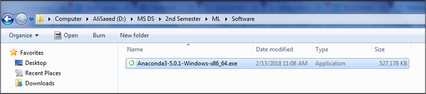

```python
from IPython.display import Image
Image(filename='Inst-1.png')
```

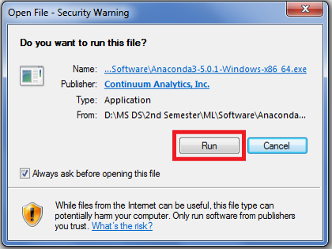

```python
Image(filename='Inst-2.png')
```

```python
Image(filename='Inst-3.png')
```

[output not shown]

- You see an Anaconda 3-5.0.1 Setup dialog box similar to the one shown in Figure.
- The exact dialog box that you see depends on which version of the Anaconda installation program you download.
- If you have a 64-bit operating system, using the 64-bit version of Anaconda is always best so that you obtain the best possible performance.
- This first dialog box tells you when you have the 64-bit version of the product.

[figure not shown]

```python
Image(filename='Inst-4.png')
```

- Click on “Next”.
- The wizard displays a licensing agreement. Be sure to read through the licensing agreement so that you know the terms of usage!

[figure not shown]

```python
Image(filename='Inst-5.png')
```

- Click on “I Agree” if you agree to the licensing agreement
- You’re asked what sort of installation type to perform, as shown in Figure. In most cases, you want to install the product just for yourself. The exception is if you have multiple people using your system and they all need access to Anaconda!

[figure not shown]

```python
Image(filename='Inst-6.png')
```

- Choose one of the installation types and then click Next
- The wizard asks where to install Anaconda on disk, as shown in Figure. The presentation assumes that you use the default location.

[figure not shown]

```python
Image(filename='Inst-7.png')
```

[figure not shown]

```python
Image(filename='Inst-8.png')
```

- Change the advanced installation options (if necessary) and then click Install
- You see an Installing dialog box with a progress bar.
- The installation process can take a few minutes, so get yourself a cup of coffee and read the comics for a while.
- When the installation process is over, you see a Next button enabled

[figure not shown]

```python
Image(filename='Inst-9.png')
```

- Click on “Next”
- The wizard tells you that the installation is complete.
- You’re ready to begin using Anaconda

[figure not shown]

```python
Image(filename='Inst-10.png')
```

- Click on “Finish”

# 1.7 Python IDE

```python
YouTubeVideo('7bGOXbqhaow',width=900, height=500)
```

[video not shown]

- There are various GUI based Python IDE that python programmers can use for better coding experience.
- General Editors and IDEs with Python Support
  - 1. Eclipse + PyDev
  - 1. Sublime Text
  - 1. Atom
  - 1. GNU Emacs
  - 1. Vi / Vim
  - 1. Visual Studio
  - 1. Visual Studio Code
- Python-Specific Editors and IDEs
  - 1. PyCharm
  - 1. Spyder
  - 1. Thonny

### Why Use IDE’s

- Save and reload code files
- Run code from within the environment
- Debugging support
- Syntax highlighting: Being able to quickly spot keywords, variables, and symbols in your code makes reading and understanding code much easier
- Automatic code formatting
- IntelliSense: code editing features including: codecompletion, parameter info, quick info, and member lists.

### Online Interpreters

- Python.org Online Console: www.python.org/shell
- Python Fiddle: www.pythonfiddle.com
- Repl.it: www.repl.it
- Trinket: www.trinket.io
- Python Anywhere: www.pythonanywhere.com

# 1.8 Jupyter Notebook

```python
YouTubeVideo('EEEZX_0FMEc',width=900, height=500)
```

[video not shown]

- Type jupyter notebook at the command line to open the dashboard
- Don't close the command line window while the Notebook is running

### Keyboard shortcuts

- Create new cells above (a) or below (b) the current cell
- Navigate using the up arrow and down arrow
- Convert the cell type to Markdown (m) or code (y)
- See keyboard shortcuts using h
- Switch to Edit mode using Enter
- Ctrl+Enter to run a cell
- Switch to Command mode using Esc

# Chapter 2: Variables, Expressions and Statements

# 2.1 Values

```python
YouTubeVideo('OH86oLzVzzw',width=900, height=500)
```

[video not shown]

- A value is one of the basic parts of a program like a letter or a number.
- These values belong to different types: for example,
  - Integers
  - Strings
  - Float
  - Complex
  - Logical.
- If you are not sure what type a value has, the interpreter can tell you

### Examples

```python
type(59)
```

```
int
```

```python
type("Hello, Word!")
```

```
str
```

```python
type(3.2)
```

```
float
```

```python
type("59")
```

```
str
```

```python
type("3.2")
```

```
str
```

```python
type('59')
```

```
str
```

```python
type('3.2')
```

```
str
```

```python
type(True)
```

```
bool
```

```python
type(False)
```

```
bool
```

```python
type('True')
```

```
str
```

```python
type('False')
```

```
str
```

```python
type(None)
```

```
NoneType
```

# 2.2 Print

```python
YouTubeVideo('xuo5KQ0cA40',width=900, height=500)
```

[video not shown]

```python
"Hello Word!"
```

```
'Hello Word!'
```

```python
print("Hello Word!")
```

```
Hello Word!
```

```python
4
```

```
4
```

```python
print(4)
```

```
4
```

- When you type a large integer, you might be tempted to use commas between groups of three digits, as in 1,000,000.
- This is not a legal integer in Python, but it is legal:

```python
print(1,000,000)
```

```
1 0 0
```

- Python interprets 1,000,000 as a comma separated sequence of integers, which it prints with spaces between.
- This is the first example of semantic error.
- Semantic Error:The code runs without producing an error message, but it doesn’t do the “right” thing.

# 2.3 Python Variables

```python
YouTubeVideo('2OYg1EzsSSs',width=900, height=500)
```

[video not shown]

- One of the most powerful features of a programming language is the ability to manipulate variables.
- A variable is a name that refers to a value.
- Variables are identifiers of a physical memory location, which is used to hold values temporarily during program execution.
- Python interpreter allocates memory based on the values data type of variable, different data types like integers, decimals, characters etc. can be stored in these variables.

### Python Variables Assignment

- Python interpreter is able to determine that what type of data is stored, so before assigning a value, variables do not need to be declared
- Python variables do not need explicit declaration to reserve memory space.
- The declaration happens automatically when you assign a value to a variable.
- The equal sign (=) is used to assign values to variables.
- It assigns the values of right side operand to left side operand.
- The left side operand of = operator is the name of a variable, and right side operand is value.

### Examples

- An assignment statement creates new variables and gives them values:
- Aassigns a string to a new variable named message;

```python
message = "Hello, I am Umer Saeed"
print(message)
type(message)
```

```
Hello, I am Umer Saeed
```

```
str
```

- In the above code, the variable name 'message' is storing a value "Hello, I am Umer Saeed" and since the value is of type string, the variable is automatically assigned the type str.
- Assigns the integer 17 to n

```python
n = 17
print(n)
type(n)
```

```
17
```

```
int
```

- In the above code, the variable name 'n' is storing a value "17" and since the value is of type int, the variable is automatically assigned the type int.
- Assigns the (approximate) value of to pi.

```python
pi = 3.1415926535897931
print(pi)
type(pi)
```

```
3.141592653589793
```

```
float
```

- In the above code, the variable name 'pi' is storing a value "3.1415926535897931" and since the value is of type *float*, the variable is automatically assigned the type float.

### Python Variables (Multiple Assignment)

```python
a, b, c = 1, 2, "Hey"
print(a)
print(b)
print(c)
```

```
1
2
Hey
```

- You can output multiple values with the print() function. For example, you can do this:

```python
planet = "Earth"
country = "Pakistan"
print(planet, country)
```

```
Earth Pakistan
```

- You can also combine the variables with other text.

```python
name = "Umer Saeed"
planet = "Earth"
country = "Pakistan"
print("My name is " + name + " and I live on " + planet+ " "+country)
```

```
My name is Umer Saeed and I live on Earth Pakistan
```

# 2.4 Variables Names

```python
message='My name is Umer Saeed'
```

```python
print(message)
```

```
My name is Umer Saeed
```

```python
print(MESSAGE)
```

```
---------------------------------------------------------------------------
NameError                                 Traceback (most recent call last)
<ipython-input-46-d833f3ddb5d8> in <module>
----> 1 print(MESSAGE)

NameError: name 'MESSAGE' is not defined
```

```python
_message='My name is Umer Saeed'
```

```python
print(_message)
```

```
My name is Umer Saeed
```

```python
$message='My name is Umer Saeed'
```

```
  File "<ipython-input-49-ce9970286205>", line 1
    $message='My name is Umer Saeed'
    ^
SyntaxError: invalid syntax
```

```python
message1='My name is Umer Saeed'
```

```python
print(message1)
```

```
My name is Umer Saeed
```

```python
mess age1='My name is Umer Saeed'
```

```
  File "<ipython-input-52-8833324be8f4>", line 1
    mess age1='My name is Umer Saeed'
            ^
SyntaxError: invalid syntax
```

```python
1team='Team Pakistan'
```

```
  File "<ipython-input-53-563e25703c7f>", line 1
    1team='Team Pakistan'
        ^
SyntaxError: invalid syntax
```

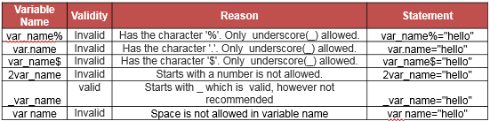

```python
from IPython.display import Image
Image(filename='Examples.png')
```

# 2.5 Python Reserved Keywords List

```python
YouTubeVideo('JvMwnGY2EjU',width=900, height=500)
```

[video not shown]

- The Python Keywords must be in your information because you can not use them as a variable name or any other identifier name.
- Keywords are reserved words in Python and used to perform an internal operation.
- All the keywords of Python contain lower-case letters only (except True , False & None).

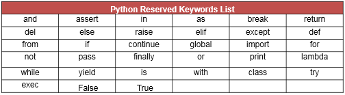

```python
Image(filename='Python_Resvered_Keywords_List.png')
```

### Choosing mnemonic variable names

- As long as you follow the simple rules of variable naming, and avoid reserved words, you have a lot of choice when you name your variables.
- In the beginning, this choice can be confusing both when you read a program and when you write your own programs.
- For example, the following three programs are identical in terms of what they accomplish, but very different when you read them and try to understand them.

### Example-1

```python
a=35.0
b=12.50
c=a*b
print(c)
```

```
437.5
```

### Example-2

```python
hours=35.0
rate=12.50
pay=hours*rate
print(pay)
```

```
437.5
```

### Example-3

```python
x1q3z9ahd = 35.0
x1q3z9afd = 12.50
x1q3p9afd = x1q3z9ahd * x1q3z9afd
print(x1q3p9afd)
```

```
437.5
```

- The Python interpreter sees all three of these programs as exactly the same but humans see and understand these programs quite differently.
- Humans will most quickly understand the intent of the second program because the programmer has chosen variable names that reflect their intent regarding what data will be stored in each variable.
- We call these wisely chosen variable names “mnemonic variable names”.
- The word mnemonic means "memory aid"
- We choose mnemonic variable names to help us remember why we created the variable in the first place!

### Finding Variables

- To know all the variables currently available in the workspace we use the following function.
- 1- %whos
- 2- %who
- 3- %who_ls

```python
%whos
```

```
Variable       Type     Data/Info
---------------------------------
Image          type     <class 'IPython.core.display.Image'>
YouTubeVideo   type     <class 'IPython.lib.display.YouTubeVideo'>
a              float    35.0
b              float    12.5
c              float    437.5
country        str      Pakistan
hours          float    35.0
message        str      My name is Umer Saeed
message1       str      My name is Umer Saeed
n              int      17
name           str      Umer Saeed
pay            float    437.5
pi             float    3.141592653589793
planet         str      Earth
rate           float    12.5
x1q3p9afd      float    437.5
x1q3z9afd      float    12.5
x1q3z9ahd      float    35.0
```

```python
%who
```

```
Image	 YouTubeVideo	 a	 b	 c	 country	 hours	 message	 message1
n	 name	 pay	 pi	 planet	 rate	 x1q3p9afd	 x1q3z9afd	 x1q3z9ahd
```

```python
%who_ls
```

```
['Image',
 'YouTubeVideo',
 'a',
 'b',
 'c',
 'country',
 'hours',
 'message',
 'message1',
 'n',
 'name',
 'pay',
 'pi',
 'planet',
 'rate',
 'x1q3p9afd',
 'x1q3z9afd',
 'x1q3z9ahd']
```

### Deleting Variables

- Variables can be deleted by using the del function.

```python
print(a,b,c)
```

```
35.0 12.5 437.5
```

```python
del a
```

```python
print(a)
```

```
---------------------------------------------------------------------------
NameError                                 Traceback (most recent call last)
<ipython-input-65-bca0e2660b9f> in <module>
----> 1 print(a)

NameError: name 'a' is not defined
```

```python
del b,c
```

```python
print(b,c)
```

```
---------------------------------------------------------------------------
NameError                                 Traceback (most recent call last)
<ipython-input-67-205fb7f33851> in <module>
----> 1 print(b,c)

NameError: name 'b' is not defined
```

### How to Swap Two Variables values

```python
YouTubeVideo('3dpJrMtxYeo',width=900, height=500)
```

[video not shown]

### Method-1

```python
a=5
b=9
print('Current Values')
print(a)
print(b)
temp=a
a=b
b=temp
print('Swap Values')
print(a)
print(b)
```

```
Current Values
5
9
Swap Values
9
5
```

### Method-2

```python
a=11
b=12
a=a+b
b=a-b
a=a-b
print(a)
print(b)
```

```
12
11
```

### Method-3 (XOR)

```python
a=11
b=12
a=a^b
b=a^b
a=a^b
print(a)
print(b)
```

```
12
11
```

### Method-4

```python
a=15
b=14
a,b=b,a
print(a)
print(b)
```

```
14
15
```

### How to get the address in Python

```python
YouTubeVideo('zPSIRv_6oPs',width=900, height=500)
```

[video not shown]

```python
a=5
print(id(a))
```

```
8791431418816
```

```python
b=5
print(id(b))
```

```
8791431418816
```

```python
id(5)
```

```
8791431418816
```

```python
k=5
print(id(k))
```

```
8791431418816
```

# 2.6 Asking the user for input

```python
YouTubeVideo('4OX49nLNPEE',width=900, height=500)
```

[video not shown]

- Sometimes we would like to take the value for a variable from the user via their keyboard
- Python provides a built-in function called input that gets input from the keyboard.
- When this function is called, the program stops and waits for the user to type something.
- When the user presses Return or Enter, the program resumes and input returns what the user typed as a string.

```python
uip=input()
```

```
2
```

```python
print(uip)
```

```
2
```

- Before getting input from the user, it is a good idea to print a prompt telling the user what to input.
- You can pass a string to input to be displayed to the user before pausing for input.

```python
name = input('What is your name?')
```

```
What is your name?Umer Saeed
```

```python
name
```

```
'Umer Saeed'
```

- The sequence \n at the end of the prompt represents a newline, which is a special character that causes a line break.

```python
name = input('What is your name?\n')
```

```
What is your name?
Umer Saeed
```

```python
name
```

```
'Umer Saeed'
```

- If you expect the user to type an integer, you can try to convert the return value to int using the int() function:

```python
prompt = 'What...is the airspeed velocity of an unladen swallow?\n'
```

```python
speed = input(prompt)
```

```
What...is the airspeed velocity of an unladen swallow?
5
```

```python
print(speed)
```

```
5
```

```python
prompt = 'What...is the airspeed velocity of an unladen swallow?\n'
```

```python
speed = int(input(prompt))
```

```
What...is the airspeed velocity of an unladen swallow?
5
```

```python
print(speed)
```

```
5
```

```python
x=int(input('Enter The First Value:\t'))
y=int(input('Enter the Second Value:\t'))
print('Sum of variables x and y is:\t')
z=x+y
print(z)
```

```
Enter The First Value:	2
Enter the Second Value:	6
Sum of variables x and y is:
8
```

# 2.7 Output of the last Function

```python
5+5
```

```
10
```

```python
_
```

```
10
```

```python
_+98
```

```
108
```

# 2.8 Comments in Python Language

```python
YouTubeVideo('Uu7C99-hG60E',width=900, height=500)
```

[video not shown]

- As programs get bigger and more complicated, they get more difficult to read.
- Formal languages are dense, and it is often difficult to look at a piece of code and figure out what it is doing, or why.
- For this reason, it is a good idea to add notes to your programs to explain in natural language what the program is doing.
- These notes are called comments, and in Python they start with the # symbol

### My first program in Python Programming

- In this case, the comment appears on a line by itself. You can also put comments at the end of a line
- percentage = (minute * 100) / 60 # percentage of an hour
- Everything from the # to the end of the line is ignored; it has no effect on the program.
- It is reasonable to assume that the reader can figure out what the code does; it is much more useful to explain why.
- This comment is redundant with the code and useless:
- v = 5 # assign 5 to v
- This comment contains useful information that is not in the code:
- v = 5 # velocity in meters/second
- Good variable names can reduce the need of the comments.
- but long names can make complex expressions hard to read, so there is a trade-off.

# 2.9 Python Help

```python
YouTubeVideo('BVXv0-1Rcc8',width=900, height=500)
```

[video not shown]

### Method-1

```python
help()
```

```
Welcome to Python 3.7's help utility!

If this is your first time using Python, you should definitely check out
the tutorial on the Internet at https://docs.python.org/3.7/tutorial/.

Enter the name of any module, keyword, or topic to get help on writing
Python programs and using Python modules.  To quit this help utility and
return to the interpreter, just type "quit".

To get a list of available modules, keywords, symbols, or topics, type
"modules", "keywords", "symbols", or "topics".  Each module also comes
with a one-line summary of what it does; to list the modules whose name
or summary contain a given string such as "spam", type "modules spam".

help> LISTS
Mutable Sequence Types

The operations in the following table are defined on mutable sequence
types. The "collections.abc.MutableSequence" ABC is provided to make
it easier to correctly implement these operations on custom sequence
types.

In the table *s* is an instance of a mutable sequence type, *t* is any
iterable object and *x* is an arbitrary object that meets any type and
value restrictions imposed by *s* (for example, "bytearray" only
accepts integers that meet the value restriction "0 <= x <= 255").

+--------------------------------+----------------------------------+-----------------------+
| Operation                      | Result                           | Notes                 |
+================================+==================================+=======================+
| "s[i] = x"                     | item *i* of *s* is replaced by   |                       |
|                                | *x*                              |                       |
+--------------------------------+----------------------------------+-----------------------+
| "s[i:j] = t"                   | slice of *s* from *i* to *j* is  |                       |
|                                | replaced by the contents of the  |                       |
|                                | iterable *t*                     |                       |
+--------------------------------+----------------------------------+-----------------------+
| "del s[i:j]"                   | same as "s[i:j] = []"            |                       |
+--------------------------------+----------------------------------+-----------------------+
| "s[i:j:k] = t"                 | the elements of "s[i:j:k]" are   | (1)                   |
```

[output cut: 54 more lines]

```
   New in version 3.3: "clear()" and "copy()" methods.

6. The value *n* is an integer, or an object implementing
   "__index__()".  Zero and negative values of *n* clear the sequence.
   Items in the sequence are not copied; they are referenced multiple
   times, as explained for "s * n" under Common Sequence Operations.

Related help topics: LISTLITERALS

help>

You are now leaving help and returning to the Python interpreter.
If you want to ask for help on a particular object directly from the
interpreter, you can type "help(object)".  Executing "help('string')"
has the same effect as typing a particular string at the help> prompt.
```

### Method-2

```python
help('LISTS')
```

```
Mutable Sequence Types

The operations in the following table are defined on mutable sequence
types. The "collections.abc.MutableSequence" ABC is provided to make
it easier to correctly implement these operations on custom sequence
types.

In the table *s* is an instance of a mutable sequence type, *t* is any
iterable object and *x* is an arbitrary object that meets any type and
value restrictions imposed by *s* (for example, "bytearray" only
accepts integers that meet the value restriction "0 <= x <= 255").

+--------------------------------+----------------------------------+-----------------------+
| Operation                      | Result                           | Notes                 |
+================================+==================================+=======================+
| "s[i] = x"                     | item *i* of *s* is replaced by   |                       |
|                                | *x*                              |                       |
+--------------------------------+----------------------------------+-----------------------+
| "s[i:j] = t"                   | slice of *s* from *i* to *j* is  |                       |
|                                | replaced by the contents of the  |                       |
|                                | iterable *t*                     |                       |
+--------------------------------+----------------------------------+-----------------------+
| "del s[i:j]"                   | same as "s[i:j] = []"            |                       |
+--------------------------------+----------------------------------+-----------------------+
| "s[i:j:k] = t"                 | the elements of "s[i:j:k]" are   | (1)                   |
|                                | replaced by those of *t*         |                       |
+--------------------------------+----------------------------------+-----------------------+
| "del s[i:j:k]"                 | removes the elements of          |                       |
|                                | "s[i:j:k]" from the list         |                       |
+--------------------------------+----------------------------------+-----------------------+
| "s.append(x)"                  | appends *x* to the end of the    |                       |
|                                | sequence (same as                |                       |
|                                | "s[len(s):len(s)] = [x]")        |                       |
+--------------------------------+----------------------------------+-----------------------+
| "s.clear()"                    | removes all items from *s* (same | (5)                   |
|                                | as "del s[:]")                   |                       |
+--------------------------------+----------------------------------+-----------------------+
| "s.copy()"                     | creates a shallow copy of *s*    | (5)                   |
|                                | (same as "s[:]")                 |                       |
+--------------------------------+----------------------------------+-----------------------+
```

[output cut: 32 more lines]

```
   that it operates by side effect, it does not return the reversed
   sequence.

5. "clear()" and "copy()" are included for consistency with the
   interfaces of mutable containers that don’t support slicing
   operations (such as "dict" and "set")

   New in version 3.3: "clear()" and "copy()" methods.

6. The value *n* is an integer, or an object implementing
   "__index__()".  Zero and negative values of *n* clear the sequence.
   Items in the sequence are not copied; they are referenced multiple
   times, as explained for "s * n" under Common Sequence Operations.

Related help topics: LISTLITERALS
```

# Chapter 3: Python Numbers

# 3.1 Python Numbers

```python
YouTubeVideo('_87ASgggEg0',width=900, height=500)
```

[video not shown]

### 1- Integer:

- An integer is a whole number (i.e. not a fraction).
- Integers can be a positive number, a negative one, or zero.
- Examples of integers: -3, -2, -1, 0, 1, 2, 3

### 2- Floating point number:

- Floating point numbers represent real numbers and are written with a decimal point dividing the integer and the fractional parts.
- Floating point number can also be in scientific notation, with E or e indicating the power of 10 (eg, +1e3 is equivalent to 1000.0).
- Examples of floats:1.0, 12.45, -10.0, -20.76789, 64.2e18.

### 3- Complex number

- A complex number takes the form a + bj where a is a real number and b is an imaginary number.
- Each argument an be any numeric type (including complex)
- The first argument can also be a string (but the second argument can't). Examples: 1.4j, -1.4j.

```python
type(1)
```

```
int
```

```python
type(-1)
```

```
int
```

```python
type(1.0)
```

```
float
```

```python
type(-1.0)
```

```
float
```

```python
type(2e3)
```

```
float
```

```python
type(-2e3)
```

```
float
```

```python
type(3.14j)
```

```
complex
```

```python
type(-3.14j)
```

```
complex
```

# 3.2 Conversion Functions

```python
YouTubeVideo('bkN0HAPR0O0',width=900, height=500)
```

[video not shown]

You can also use functions such as;

- int()
- float()
- complex()

to make an explicit conversion between one number type and another.

```python
a=100
type(a)
```

```
int
```

```python
type(float(a))
```

```
float
```

```python
type(complex(a))
```

```
complex
```

```python
print(type(bool(a)))
```

```
<class 'bool'>
```

```python
type(bool(a))
```

```
bool
```

# 3.3 Numbering Systems

```python
YouTubeVideo('oLb7x1Tgddw',width=900, height=500)
```

[video not shown]

- These following numbering systems tend to be more popular in mathematics and computing.
  - 1- Decimal Number System
  - 2- Binary Number System
  - 3- Octal Number System
  - 4- Hexadecimal Number System
- In Python, you can specify the numbering system a number uses by using a two-digit prefix as follows:

```python
Image(filename='NumberSystemPrefix.png')
```

[output not shown]

- The prefix can be uppercase or lowercase.

### 1-Decimal Number System

- The decimal numbering system is the most widely used system in the modern world.
- Also called base-ten, the decimal system has 10 as its base, and uses the digits 0 to 9.

### 2-Binary Number System

- There are other numbering systems though, that don't use 10 as its base.
- The binary system is base-two (uses the digits 1 and 0)

```python
print("...", 0b001, 0b010, 0b011, 0b100, 0b101, "...")
```

```
... 1 2 3 4 5 ...
```

### 3-Octal Number System

- The octal system is base-eight (uses digits 0 to 7)

```python
print("...", 0o05, 0o06, 0o07, 0o10, 0o11, 0o12, 0o13, 0o14, "...")
```

```
... 5 6 7 8 9 10 11 12 ...
```

### 4-Hexadecimal Number System

- The hexadecimal system is base-sixteen (uses digits 0 to 9, and letters A to F).

```python
print("...", 0x7, 0x8, 0x9, 0xa, 0xb, 0xc, 0xd, 0xe, 0xf, 0x10, 0x12, 0x13, "...")
```

```
... 7 8 9 10 11 12 13 14 15 16 18 19 ...
```

### Conversion Functions

- You can also use functions such as hex() and oct() to return an integer as a hexadecimal, binary and octal number.

```python
a=100
oct(a)
```

```
'0o144'
```

```python
a=100
hex(a)
```

```
'0x64'
```

```python
a=100
bin(a)
```

```
'0b1100100'
```

# 3.4 Operators and Operands

```python
YouTubeVideo('v5MR5JnKcZI',width=900, height=500)
```

[video not shown]

- Python operators are symbols that are used to perform mathematical or logical manipulations.
- Operands are the values or variables with which the operator is applied to, and values of operands can manipulate by using the operators.

### Example

```python
6+2
```

```
8
```

- There are two operands and a plus (+) operator, and the result turns 8
- Here a single operator is used to manipulate the values.
- The +, -, *, / and ** does addition, subtraction, multiplication, division & exponentiation respectively.

```python
6-4
```

```
2
```

```python
6*2
```

```
12
```

```python
6/3
```

```
2.0
```

```python
6**2
```

```
36
```

# 3.5 Python Expressions

- An expression is a combination of values, variables, and operators.

```python
hours=35.0
rate=12.50
pay=hours*rate
print(pay)
```

```
437.5
```

# 3.6 Order of Operations

```python
YouTubeVideo('Ui2qrIaBLK8',width=900, height=500)
```

[video not shown]

- When more than one operator appears in an expression, the order of evaluation depends on the rules of precedence.
- For mathematical operators, Python follows mathematical convention.
- The acronym PEMDAS is a useful way to remember the rules:
- Parentheses have the highest precedence and can be used to force an expression to evaluate in the order you want.

### Example

```python
2 * (3-1)
```

```
4
```

```python
(1+1)**(5-2)
```

```
8
```

- You can also use parentheses to make an expression easier to read, as in (min * 100) / 60, even if it doesn’t change the result.
- Exponentiation has the next highest precedence.

```python
2*(3-1)
```

```
4
```

```python
3*1**3
```

```
3
```

- Multiplication and Division have the same precedence, which is higher than Addition and Subtraction, which also have the same precedence.

```python
2*3-1
```

```
5
```

```python
6+4/2
```

```
8.0
```

- Operators with the same precedence are evaluated from left to right.
- Expression 5-3-1 is 1, because the 5-3 happens first and then 1 is subtracted from 2.
- When in doubt, always put parentheses in your expressions to make sure the computations are performed in the order you intend.